# Modeli optičnih naprav

### Gregor Kržmanc, 7.4.2021

V vaji sestavimo projekcijski aparat, daljnogled in mikroskop ter jim določimo povečavo.

## 1. Projekcijski aparat

Sestavljeni aparat je prikazan na spodnji skici. Sestavljen je iz svetila, kondenzorja in objektiva. Sliko S diapozitiva P projiciramo na zaslon. Kondenzor postavimo pred diapozitiv zato, da dobimo vzporedne žarke in je zato slika enakomerno osvetljena.

### Meritve

$$ f_k = 13 cm \pm 5 mm $$$$ f_{obj} = (139 \pm 3) mm $$

Višina slike $ S = 7.7 cm \pm 2 mm $

Višina diapozitiva (predmeta) $ P = 3.4 cm \pm 2 mm$ $$a = 18.5 cm \pm 3 mm $$ $$b = 46.5 cm \pm 5 mm $$

Povečava

$$M_{izmerjena} = S/P \approx 2.3 \pm 0.2 $$$$M_{izračunana} = b/a = 2.5 \pm 0.05 $$

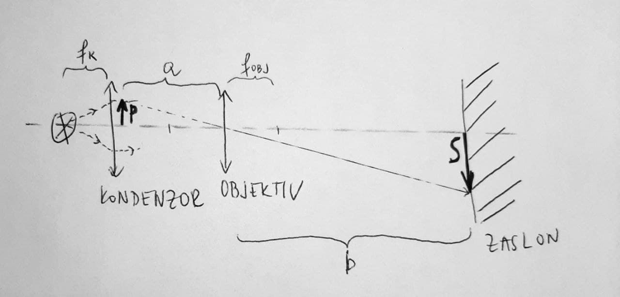

```python
from IPython.display import Image
Image(filename='proj_aparat.jpg')
```

## 2. Daljnogled

Sestavimo daljnogled, kot je prikazan na skici:

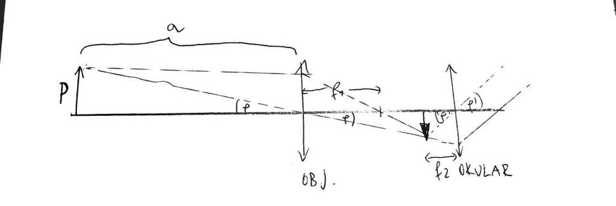

```python
Image(filename='daljnogled.jpg')
```

### Meritve

Gor. razdalji preberemo z leč: $$ f_1 = 51 cm $$ $$ f_2 = 8.7 cm $$ $$ a = 12 m \pm 2 m $$ Oddaljenost nitnega križa od ravnine okularja: $$ q = 5.8 cm \pm 0.5 cm $$ Razdalja med dvema razdelkoma na okularju: $$ r = (1.5 \pm 0.5) mm $$ Opazujemo predmet na razdalji a, visok $x = 2.0 cm $. Čez en razdelek se razteza pribl. $N=4$ predmetov.

Povečava $$ M_{izračunana} = \frac{f_1}{f_2} \frac{1}{1-f_1 / a} = 6.12 \pm 0.05$$ Izmerjeno povečavo ocenimo iz razmerja zornih kotov. $$ M_{izmerjena} = \frac{r/q}{N*x/a} \approx 3.9 \pm 1.5 $$

### 2.1 Holandski daljnogled

Podoben kot zgornji, le da ima za okular razpršilno lečo. (vir: http://fizika.marcus.si/wp-content/uploads/2012/08/astronomski_teleskop_daljnogled.pdf)

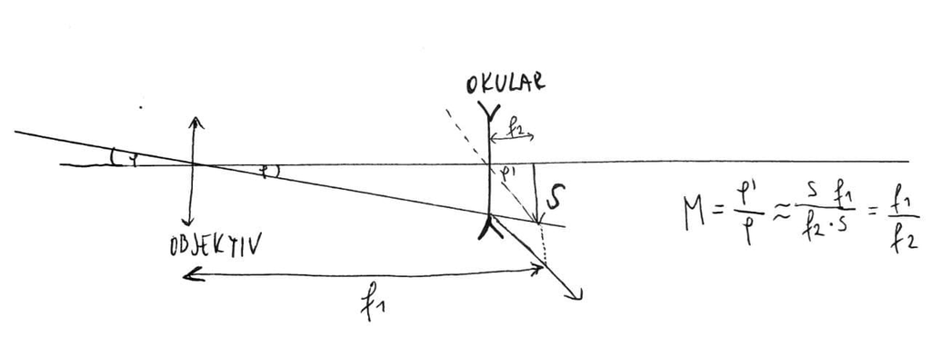

```python
Image(filename='holandski_daljnogled.jpg')
```

## 3. Mikroskop

Sestavimo mikroskop s skice spodaj. Povečavo definiramo kot razmerje tangensov zornega kota, pot katerim vidimo predmet skozi mikroskop, in zornega kota, pri katerem bi ga videli pri $r=25cm$. $$ M = N_1 * N_2 = \frac{d r}{f_1 f_2}$$ $$N_1 = d/f_1 $$ $$N_2 = r/f_2 $$ $d $ je razdalja med notranjima goriščema obeh leč.

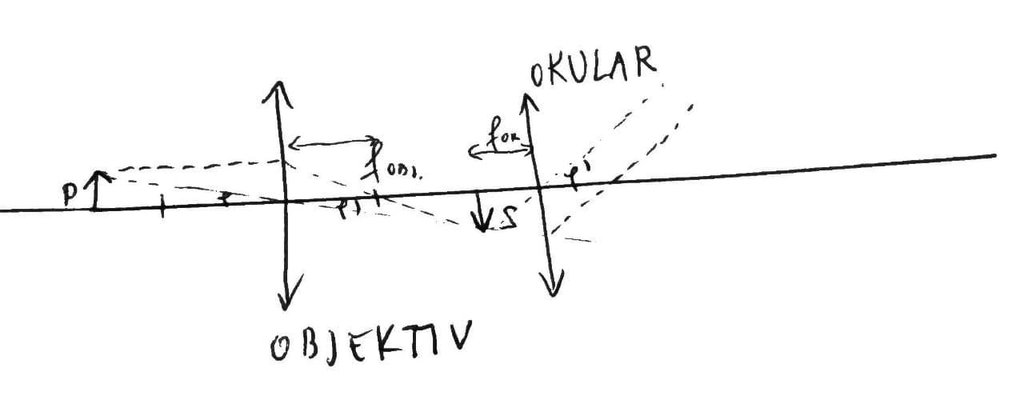

```python
Image(filename='mikroskop.jpg')
```

## Meritve

Goriščne razdalje preberemo z leč: $$f_{obj.} = 8.7 cm$$ $$f_{ok.} = 5.8 cm $$ $$ d = (15.0 \pm 1) cm$$ Povečavo je težko oceniti na oko, zato ocenimo velikostni razred $$ M \approx 10 $$

Izračunana povečava: $$ M = 7.4 \pm 0.5 $$